# Predicting Adoption Speed

Laura Williams and Shannon Moldowan

7/12/2020

### Introduction

The website PetFinder.my, founded in 2008, is Malaysia’s leading animal welfare platform. The data posted on Kaggle for the Adoption Prediction Competition contains 24 variables, images, and sentiment data.

### Data Preparation

For this problem, we decided to attempt to predict adoption speed with only the data provided. The data and data fields included may be viewed at https://www.kaggle.com/c/petfinder-adoption-prediction/data. Below are the first 5 observations of the training data provided.

```
##   Type        Name Age Breed1 Breed2 Gender Color1 Color2 Color3 MaturitySize
## 1    2      Nibble   3    299      0      1      1      7      0            1
## 2    2 No Name Yet   1    265      0      1      1      2      0            2
## 3    1      Brisco   1    307      0      1      2      7      0            2
## 4    1        Miko   4    307      0      2      1      2      0            2
## 5    1      Hunter   1    307      0      1      1      0      0            2
##   FurLength Vaccinated Dewormed Sterilized Health Quantity Fee State
## 1         1          2        2          2      1        1 100 41326
## 2         2          3        3          3      1        1   0 41401
## 3         2          1        1          2      1        1   0 41326
## 4         1          1        1          2      1        1 150 41401
## 5         1          2        2          2      1        1   0 41326
##                          RescuerID VideoAmt
## 1 8480853f516546f6cf33aa88cd76c379        0
## 2 3082c7125d8fb66f7dd4bff4192c8b14        0
## 3 fa90fa5b1ee11c86938398b60abc32cb        0
## 4 9238e4f44c71a75282e62f7136c6b240        0
## 5 95481e953f8aed9ec3d16fc4509537e8        0
##                                                                                                                                                                                                                                                                                                          …
## 1                                   Nibble is a 3+ month old ball of cuteness. He is energetic and playful. I rescued a couple of cats a few months ago but could not get them neutered in time as the clinic was fully scheduled. The result was this little kitty. I do not have enough space and funds…
## 2                                                                                                                                                                                                                                                                                    I just found it alon…
## 3 Their pregnant mother was dumped by her irresponsible owner at the roadside near some shops in Subang Jaya. Gave birth to them at the roadside. They are all healthy and adorable puppies. Already dewormed, vaccinated and ready to go to a home. No tying or caging for long hours as guard dogs. How…
## 4                                                                                                                                                                                                                                                        Good guard dog, very alert, active, obedience wa…
## 5    This handsome yet cute boy is up for adoption. He is the most playful pal we've seen in our puppies. He loves to nibble on shoelaces , Chase you at such a young age. Imagine what a cute brat he will be when he grows. We are looking for a loving home for Hunter , one that will take care of hi…
##       PetID PhotoAmt AdoptionSpeed
## 1 86e1089a3        1             2
## 2 6296e909a        2             0
## 3 3422e4906        7             3
## 4 5842f1ff5        8             2
## 5 850a43f90        3             2
```

#### Initial Variable Selection

We first removed the identifier fields RescuerID and PetID. After manually searching through the Descriptions, we decided that attemting NLP on the text was out of our scope, and decided to remove it (also due to the uncertainty of unseen input). We drew the same conclusion after considering the Name variable. For example, many of the pets had no name listed. However, the format in which this was indicated ranged widely, making classifying pets as having names or not difficult. Listed below were the variables remaining.

```
##  [1] "Type"          "Age"           "Breed1"        "Breed2"
##  [5] "Gender"        "Color1"        "Color2"        "Color3"
##  [9] "MaturitySize"  "FurLength"     "Vaccinated"    "Dewormed"
## [13] "Sterilized"    "Health"        "Quantity"      "Fee"
## [17] "VideoAmt"      "PhotoAmt"      "AdoptionSpeed"
```

Next, we examined the remaining variables.

We first looked at the Age variable, which was recorded in months. Since the majority of the ages for the pets listed were about 2 years and younger, we decided to split the age variable into 6 months old or younger (as many people desire young animals), indicating puppies and kittens, and all other ages. Below is the frequency of the younger and older pets.

```
##
##   Old Young
##  4779 10214
```

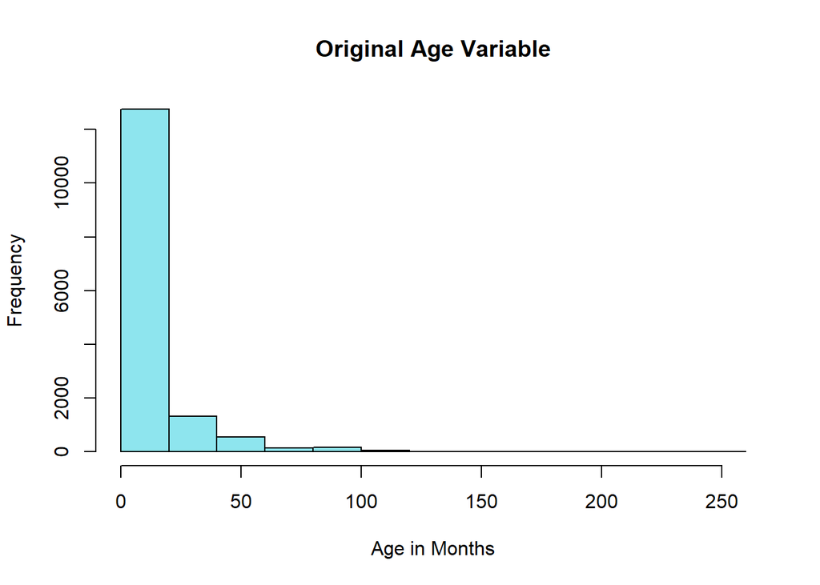

Next, we examined the Breed variables (1 and 2). Due to the number of different breeds, and the majority of pets listed without a second breed, we created a new variable indicating whether a pet was a mixed breed (2 breeds) or not. Below is the frequency of mixed/non mixed breeds.

```
##
##    No   Yes
## 10762  4231
```

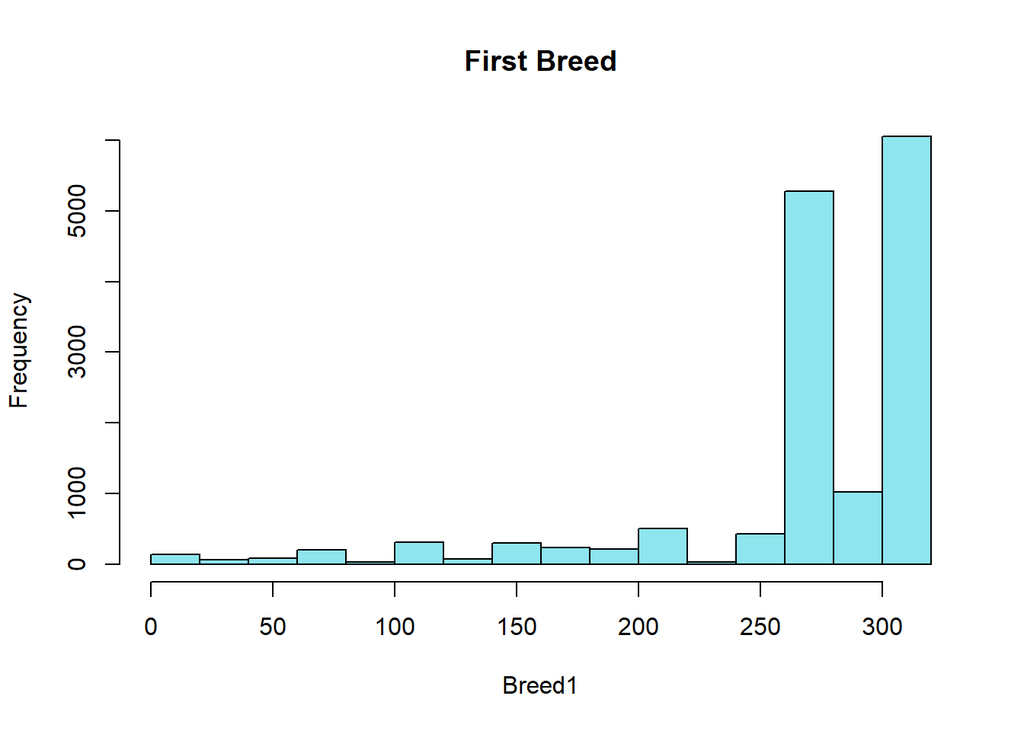

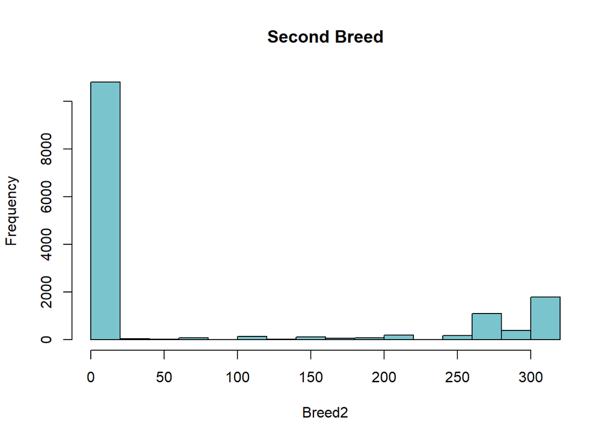

Since three color variables were included, we decided that we would similarly create a new variable indicating how many colors a pet had.

```
##
##  1 Color 2 Colors 3 Colors
##     4471     6133     4389
```

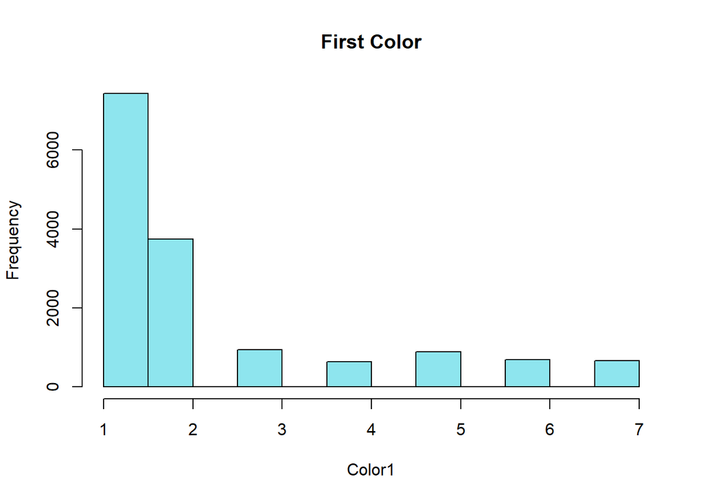

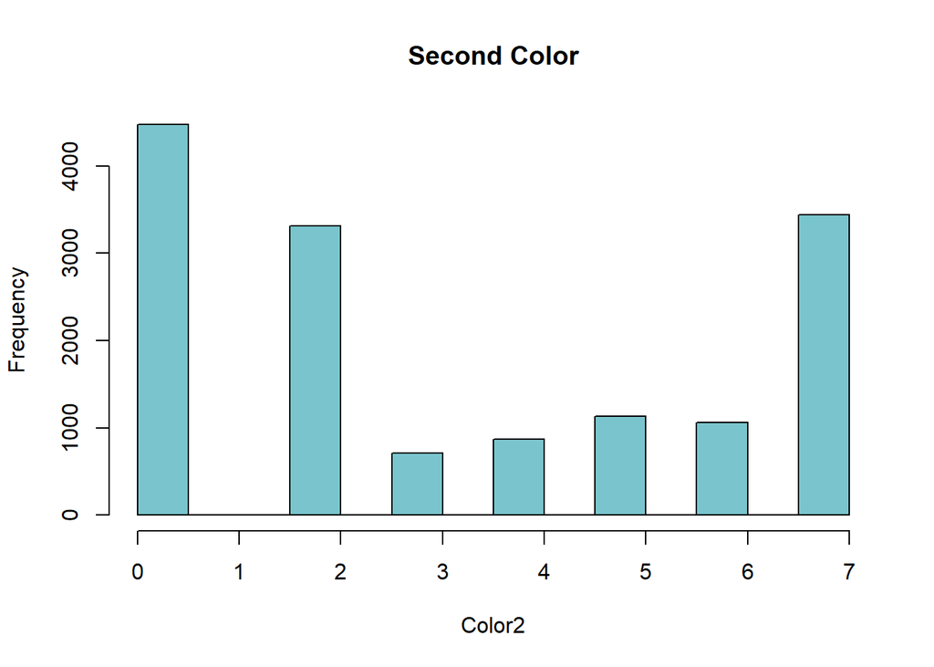

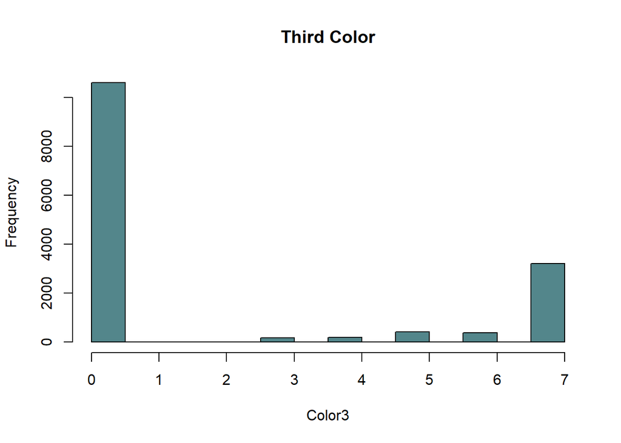

Next, we looked at the Fee variable. Due to the majority of pets having no fee listed and the wide range of fees that were listed, we created a new variable to indicate if there was a fee or not.

```
##
##    Fee No fee
##   2330  12663
```

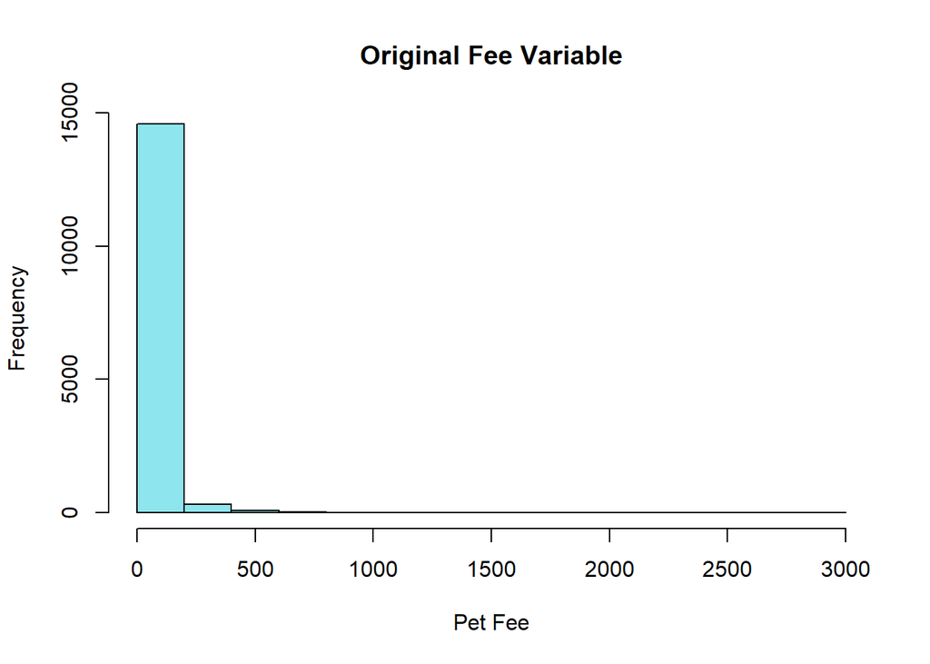

Next, we examined the photo and video amount variables. Since the majority of the number of photos falls between 1 and 5, we created a variable that included listings with no photos, 1 to 5 photos, and all other amounts.

The first table shows the original variable frequencies, and the second shows the new variable frequencies.

```
##
##    0    1    2    3    4    5    6    7    8    9   10   11   12   13   14   15
##  341 3075 2518 2511 1881 2147  621  432  314  231  190  184   97   86   78   50
##   16   17   18   19   20   21   22   23   24   25   26   27   28   29   30
##   39   27   18   20   25   16    9   12   15    8   10    6    7    6   19
```

```
##
##     0     1     2
##   341 12132  2520
```

Since the majority of listings had no videos, we created a new variable indicating whether videos were listed or not.

```
##
## No video Video(s)
##    14419      574
```

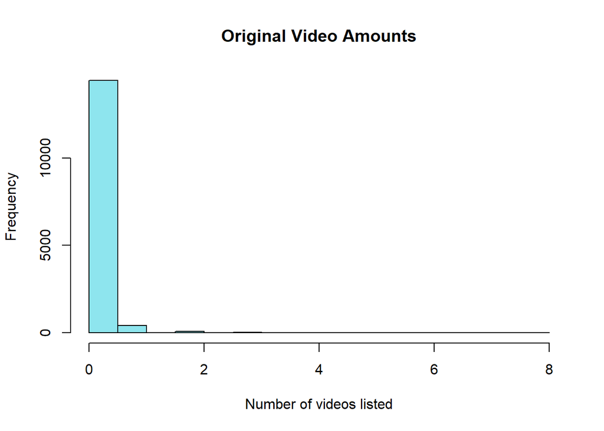

Lastly, we examined Quantity. Since the majority of listings listed only 1 pet, we created a new variable indicating whether 1 or multiple pets were listed.

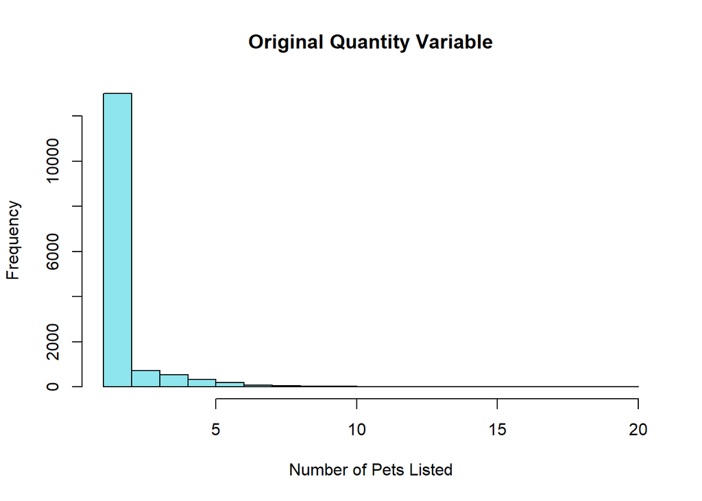

```
##
##           1 More than 1
##       11565        3428
```

#### Check for correlated variables

After transforming/creating new variables, we checked for any correlations between variables. As seen in the plot below, the variables Dewormed and Vaccinated are highly correlated, so we chose to drop the Dewormed variable.

We also noticed that none of the variables were correlated with Adoption Speed. The second plot below shows the correlation matrix of the included variables before we created new ones.

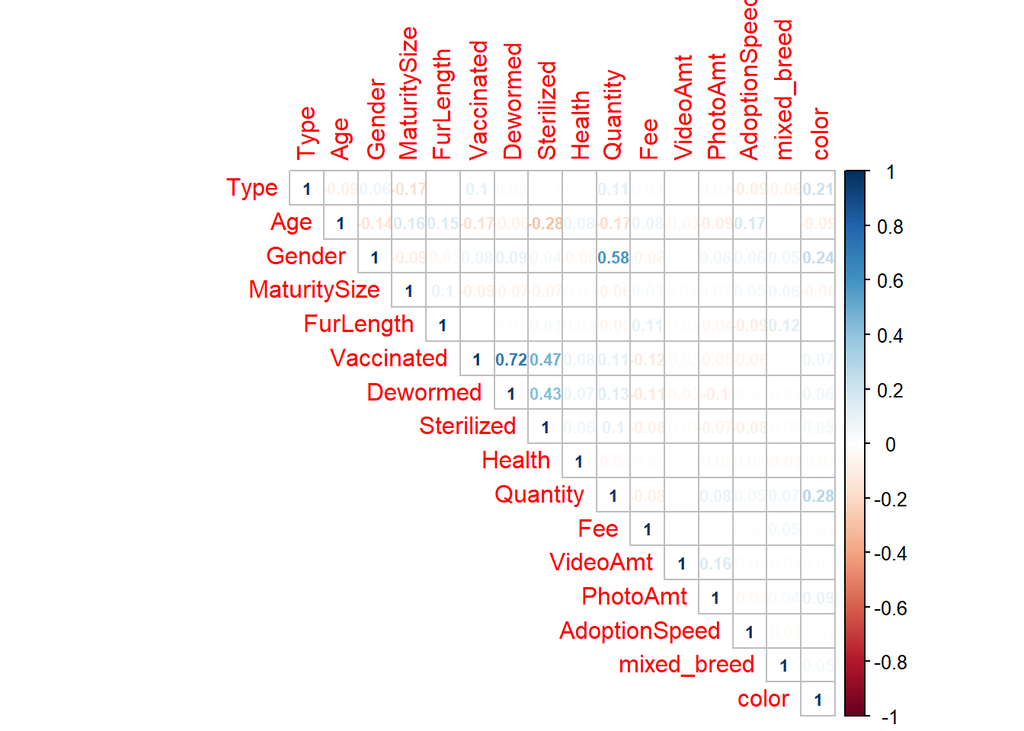

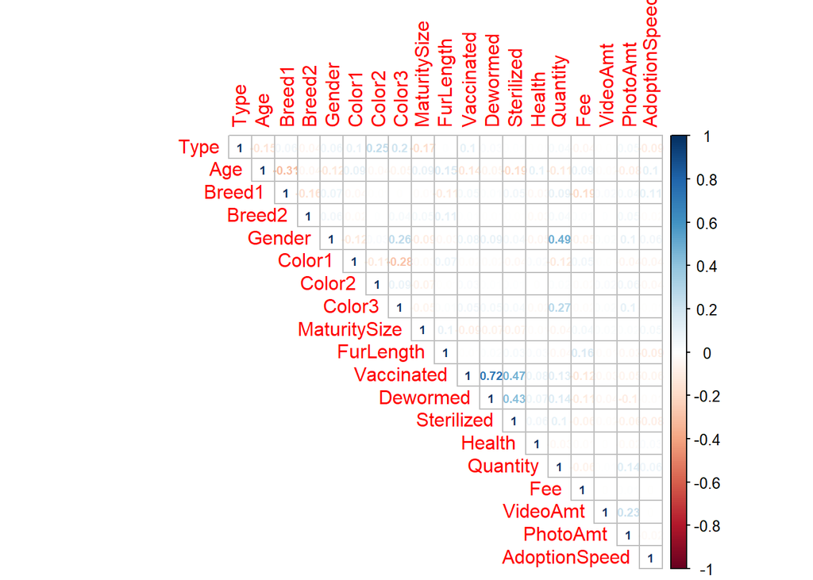

### Model Preparation

```
##   Type Age Gender MaturitySize FurLength Vaccinated Sterilized Health Quantity
## 1    1   0      0            1         1          1          1      1        0
## 2    1   0      0            2         2          2          2      1        0
## 3    0   0      0            2         2          0          1      1        0
## 4    0   0      1            2         1          0          1      1        0
## 5    0   0      0            2         1          1          1      1        0
## 6    1   0      1            2         1          1          1      1        0
##   Fee VideoAmt PhotoAmt AdoptionSpeed mixed_breed color
## 1   1        0        1             2           0     1
## 2   0        0        1             0           0     1
## 3   0        0        2             3           0     1
## 4   1        0        2             2           0     1
## 5   0        0        1             2           0     0
## 6   0        0        1             2           0     1
```

### Model Preparation

With the absence of any high or relatively high correlations between the features and Adoption Speed, we were not optimistic about producing a working model.

We first tried to fit a simple MLP model. Our initial model fit parameters were:

- Epochs = 100
- Batch size = 32
- Validation split = 20%
- Optimizer = adam

```r
model <- keras_model_sequential() %>%
  layer_dense(units = 16, activation = "relu",input_shape = c(ncol(train_df))) %>%
  layer_dense(units = 5, activation = "softmax")

model %>% compile(
  optimizer = optimizer_adam(),
  loss = "categorical_crossentropy",
  metrics = c("accuracy")
)

history <- model %>% fit(
  (train_df),
  (train_labels),
  epochs = 100,
  batch_size=32,
  validation_split=.2
)

model %>%  evaluate(test_df,test_labels)
```

```
##      loss  accuracy
## 1.3980029 0.3639103
```

Increasing the number of units in the first layer and adding dropout produced similar results. Adding additional layers also showed no real change in accuracy or loss.

```r
model <- keras_model_sequential() %>%
  layer_dense(units = 128, activation = "relu",input_shape = c(ncol(train_df))) %>%
  layer_dropout(rate=.5) %>%
  layer_dense(units = 5, activation = "softmax")

model %>% compile(
  optimizer = optimizer_adam(),
  loss = "categorical_crossentropy",
  metrics = c("accuracy")
)

history <- model %>% fit(
  (train_df),
  (train_labels),
  epochs = 100,
  batch_size=32,
  validation_split=.2
)

model %>%  evaluate(test_df,test_labels)
```

```
##      loss  accuracy
## 1.3949804 0.3729495
```

```r
model <- keras_model_sequential() %>%
  layer_dense(units = 128, activation = "relu",input_shape = c(ncol(train_df))) %>%
  layer_dropout(rate=.5) %>%
  layer_dense(units = 64,activation = "relu") %>%
  layer_dropout(rate=.5) %>%
  layer_dense(units = 5, activation = "softmax")

model %>% compile(
  optimizer = optimizer_adam(),
  loss = "categorical_crossentropy",
  metrics = c("accuracy")
)

history <- model %>% fit(
  (train_df),
  (train_labels),
  epochs = 100,
  batch_size=128,
  validation_split=.2
)

model %>%  evaluate(test_df,test_labels)
```

```
##      loss  accuracy
## 1.3918320 0.3809843
```

We tried many combinations of unit size, number of layers, batch sizes, amount of dropout, weight regularization, learning rates, class weights, and kernel initialization, and were unable to achieve accuracy much better than the network randomly guessing or a loss close to or below 1. Below are a few examples we attempted to fit.

```r
model <- keras_model_sequential() %>%
  layer_dense(units = 256, activation = "relu",input_shape = c(ncol(train_df))) %>%
  layer_dropout(rate=.5) %>%
  layer_dense(units = 128,activation = "relu") %>%
  layer_dropout(rate=.5) %>%
  layer_dense(units = 128,activation = "relu") %>%
  layer_dropout(rate=.5) %>%
  layer_dense(units = 5, activation = "softmax")

model %>% compile(
  optimizer = optimizer_adam(),
  loss = "categorical_crossentropy",
  metrics = c("accuracy")
)

history <- model %>% fit(
  (train_df),
  (train_labels),
  epochs = 100,
  batch_size=128,
  validation_split=.2
)

model %>%  evaluate(test_df,test_labels)
```

```
##      loss  accuracy
## 1.3926594 0.3752929
```

```r
model <- keras_model_sequential() %>%
  layer_dense(units = 128, activation = "relu",input_shape = c(ncol(train_df))) %>%
  layer_dropout(rate=.5) %>%
  layer_dense(units = 64,activation = "relu") %>%
  layer_dropout(rate=.5) %>%
  layer_dense(units = 32,activation = "relu") %>%
  layer_dropout(rate=.5) %>%
  layer_dense(units = 16,activation = "relu") %>%
  layer_dense(units = 5, activation = "softmax")

model %>% compile(
  optimizer = optimizer_adam(),
  loss = "categorical_crossentropy",
  metrics = c("accuracy")
)

history <- model %>% fit(
  (train_df),
  (train_labels),
  epochs = 100,
  batch_size=256,
  validation_split=.2
)

model %>%  evaluate(test_df,test_labels)
```

```
##      loss  accuracy
## 1.3888098 0.3766321
```

```r
model <- keras_model_sequential() %>%
  layer_dense(units = 128, activation = "relu",kernel_regularizer = regularizer_l1(.0001),
              input_shape = c(ncol(train_df))) %>%
  layer_dropout(rate=.5) %>%
  layer_dense(units = 64,activation = "relu",kernel_regularizer = regularizer_l1(.0001)) %>%
  layer_dense(units = 5, activation = "softmax")

model %>% compile(
  optimizer = optimizer_adam(),
  loss = "categorical_crossentropy",
  metrics = c("accuracy")
)

history <- model %>% fit(
  (train_df),
  (train_labels),
  epochs = 100,
  batch_size=256,
  validation_split=.2
)

model %>%  evaluate(test_df,test_labels)
```

```
##      loss  accuracy
## 1.4111840 0.3742886
```

```r
as.numeric(table(train_df_copy[,13])[1])/table(train_df_copy[,13])
```

```
##
##         0         1         2         3         4
## 1.0000000 0.1359968 0.1046259 0.1284299 0.1007173
```

```r
model <- keras_model_sequential() %>%
  layer_dense(units = 128, activation = "relu",input_shape = c(ncol(train_df))) %>%
  layer_dropout(rate=.5) %>%
  layer_dense(units = 64,activation = "relu") %>%
  layer_dropout(rate=.5) %>%
  layer_dense(units = 5, activation = "softmax")

model %>% compile(
  optimizer = optimizer_adam(),
  loss = "categorical_crossentropy",
  metrics = c("accuracy")
)

history <- model %>% fit(
  (train_df),
  (train_labels),
  epochs = 100,
  batch_size=64,
  validation_split=.2,
  class_weight = list("0" = 1, "1" = 0.136, "2" = 0.104, "3" = 0.128, "4" = 0.10)
)

model %>%  evaluate(test_df,test_labels)
```

```
##      loss  accuracy
## 1.5184113 0.3009709
```

### Discussion

After many attempts to increase the prediction accuracy, it became clear that we were unable to fit the data adequately. Above are a handful of the many models we built in attempts to create a working model.

Another ML model may be more appropriate to fit the data. Using the image and/or sentiment data may have improved the training of the model. However, based on our proposal to use only the listing data, this was our best attempt to build a working model.